# Preterm Birth Detection using electrohysteography

Sohaib Zafar and Sanna Herrala

## Task:

- Use EHG data from 39 women to build a classifier for predicting pre-term birth
- Differentiate the EHG signals into two classes: 1 for the mothers that gave preterm birth and 0 for the mothers with normal pregnancy
- Train 2 classifiers and compare how well they do

### Library imports

```python
#for importing the data
from glob import glob
import os
from pandas import read_csv

#for preprocessing the data
import numpy as np
import pandas as pd
import matplotlib.pyplot as plt
from scipy import fft, signal, stats
from sklearn.preprocessing import MinMaxScaler

# Machine learning package - scikit-learn
from sklearn import metrics
from sklearn.preprocessing import StandardScaler
from sklearn.model_selection import train_test_split, cross_val_score, LeaveOneOut, GridSearchCV
from sklearn.neighbors import KNeighborsClassifier, KNeighborsRegressor
from sklearn.linear_model import Ridge
from sklearn.naive_bayes import GaussianNB
from sklearn import tree
from sklearn.metrics import accuracy_score, precision_score, recall_score, f1_score

# to stop warnings from showing
import warnings
warnings.filterwarnings('ignore')

%matplotlib inline
```

## Preprocessing and filtering

### Data import

```python
# preparing the file paths for all data files using glob
dataPathNormal = 'dataset/normal/'
dataPathPreterm = 'dataset/preterm/'
dataFilesNormal = glob(dataPathNormal + '*.csv')
dataFilesPreterm = glob(dataPathPreterm + '*.csv')

# data is imported as pandas dataframes that are arranged into arrays
# normal and preterm data are separated into their own arrays
normalData = []
pretermData = []

for i in dataFilesNormal:
    i = read_csv(i)
    normalData.append(i)

for i in dataFilesPreterm:
    i = read_csv(i)
    pretermData.append(i)

# example of what one imported file looks like
# each recording consists of time readings and three channels. Each recording is 30 minutes long
print(pretermData[3].head())

# double checking that all files were imported by checking the length of the arrays that hold the imported data
# there should be 20 in normal data and 19 in preterm data
print("\nAmount of normal birth data files imported: ",len(normalData))
print("\nAmount of preterm birth data files imported: ",len(pretermData))
```

```
         time     s1     s2     s3
0  '0:00.000'  0.070  0.020  0.018
1  '0:00.050'  0.071  0.021  0.018
2  '0:00.100'  0.072  0.023  0.018
3  '0:00.150'  0.080  0.023  0.015
4  '0:00.200'  0.079  0.025  0.014

Amount of normal birth data files imported:  20

Amount of preterm birth data files imported:  19
```

### Plotting example data

Plotting one reading from both groups to see what the raw data looks like

```python
# this is just to make plotting the example the data easier
normalDf = normalData[10]
pretermDf = pretermData[10]

# utility functions for plotting the data later
fs=20 #sampling frequency
def getSignalLength(df):
  sigLength = len(df['s1'].to_numpy())
  return sigLength

def getTimeInSeconds(df):
  length = getSignalLength(df)
  seconds = np.linspace(0, length/fs, length)
  return seconds
```

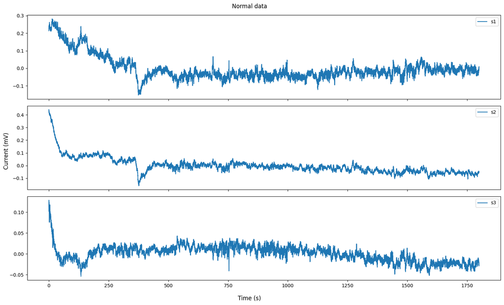

```python
seconds = getTimeInSeconds(normalDf)
fig, axes = plt.subplots(3, figsize=(15,9), sharex=True)
axes[0].plot(seconds, normalDf['s1'], label="s1")
axes[1].plot(seconds, normalDf['s2'], label="s2")
axes[2].plot(seconds, normalDf['s3'], label="s3")
fig.suptitle('Normal data')
fig.supxlabel('Time (s)')
fig.supylabel('Current (mV)')
axes[0].legend()
axes[1].legend()
axes[2].legend()
plt.tight_layout()
```

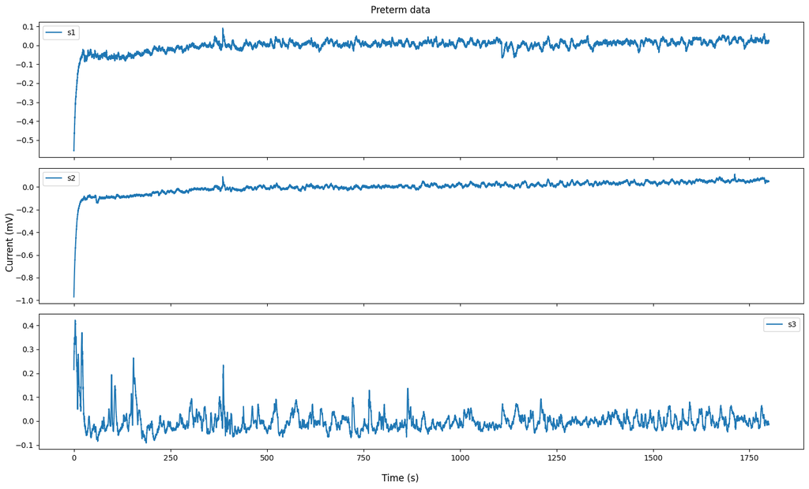

```python
seconds = getTimeInSeconds(pretermDf)
fig, axes = plt.subplots(3, figsize=(15,9), sharex=True)
axes[0].plot(seconds, pretermDf['s1'], label="s1")
axes[1].plot(seconds, pretermDf['s2'], label="s2")
axes[2].plot(seconds, pretermDf['s3'], label="s3")
fig.suptitle('Preterm data')
fig.supxlabel('Time (s)')
fig.supylabel('Current (mV)')
axes[0].legend()
axes[1].legend()
axes[2].legend()
plt.tight_layout()
```

### Fourier transform and filtering

```python
# Setting up the functions for transforming and filtering the data


# using Fourier transform to transform the data into the frequency domain

def fourierTransform(dataArray):
  transformedDataArray = []
  for [i, j] in enumerate (dataArray):
    S1 = dataArray[i]['s1']
    S2 = dataArray[i]['s2']
    S3 = dataArray[i]['s3']

    sigLength = len(S1.to_numpy())
    #fx = fft.rfftfreq(sigLength, 1/fs)
    fyS1 = fft.rfft(S1.values)
    fyS2 = fft.rfft(S2.values)
    fyS3 = fft.rfft(S3.values)
    #data = {'fx':fx, 's1':fyS1, 's2':fyS2,'s3':fyS3}
    data = {'s1':fyS1, 's2':fyS2,'s3':fyS3}

    df = pd.DataFrame(data)
    transformedDataArray.append(df)
  return transformedDataArray

# setting up a high-pass Butterworth filter to apply to the signals
# the filtering frequency was chosen by plotting different options
# and choosing the best looknig one
highcut = 0.05
order = 5
fs = 20
nyq = 0.5 * fs
high = highcut/nyq
b,a = signal.butter(order, high, btype='high', analog=False)

def filterSignalData(dataArray):
  filteredDataArray = []
  for [i,j] in enumerate (dataArray):
    signalS1 = dataArray[i]['s1']
    signalS2 = dataArray[i]['s2']
    signalS3 = dataArray[i]['s3']

    filteredS1 = signal.filtfilt(b,a, signalS1)
    filteredS2 = signal.filtfilt(b,a, signalS2)
    filteredS3 = signal.filtfilt(b,a, signalS3)
    data = {'s1':filteredS1,'s2': filteredS2, 's3':filteredS3}
    df = pd.DataFrame(data)
    filteredDataArray.append(df)
  return filteredDataArray


# an inverse Fourier trandform function to transform data
# from frequency to time domain
def inverseFourierTransform(dataArray):
  transformedDataArray = []
  for [i, j] in enumerate (dataArray):
    S1 = dataArray[i]['s1']
    S2 = dataArray[i]['s2']
    S3 = dataArray[i]['s3']

    sigLength = len(S1.to_numpy())

    fyS1 = fft.ifft(S1.values)
    fyS2 = fft.ifft(S2.values)
    fyS3 = fft.ifft(S3.values)
    data = {'s1':fyS1, 's2':fyS2,'s3':fyS3}
    df = pd.DataFrame(data)
    transformedDataArray.append(df)
  return transformedDataArray
```

```python
# processing the data in different ways to find out what produces the best looking result


# Fourier transform the original signal
ftDataNormal = fourierTransform(normalData)
ftDataPreterm = fourierTransform(pretermData)

# Filter original data after Fourer transform
filteredFtDataNormal = filterSignalData(ftDataNormal)
filteredFtDataPreterm = filterSignalData(ftDataPreterm)

# Apply inverse Fourier transform to data after Fourier transform and filtering
inverseFilteredFtDataNormal = inverseFourierTransform(filteredFtDataNormal)
inverseFilteredFtDataPreterm = inverseFourierTransform(filteredFtDataPreterm)

# Filter the original data before a transform
filteredNormal = filterSignalData(normalData)
filteredPreterm = filterSignalData(pretermData)

# Fourier transform the filtered original data
ftFilteredNormal = fourierTransform(filteredNormal)
ftFilteredPreterm = fourierTransform(filteredPreterm)
```

Recap of all the data arrays and how the data in them has been transformed

[output not shown]

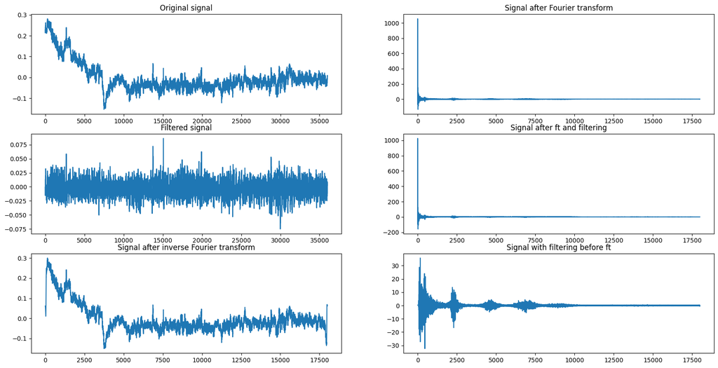

```python
# plotting an example from all processed signals to compare them

fig, axes = plt.subplots(3,2, figsize=(20,10))
axes[0,0].plot(normalData[10]['s1'])
axes[0,0].set_title('Original signal')
axes[0,1].plot(ftDataNormal[10]['s1'])
axes[0,1].set_title('Signal after Fourier transform')

axes[1,0].plot(filteredNormal[10]['s1'])
axes[1,0].set_title('Filtered signal')
axes[1,1].plot(filteredFtDataNormal[10]['s1'])
axes[1,1].set_title('Signal after ft and filtering')

axes[2,0].plot(inverseFilteredFtDataNormal[10]['s1'])
axes[2,0].set_title('Signal after inverse Fourier transform')
axes[2,1].plot(ftFilteredNormal[10]['s1'])
axes[2,1].set_title('Signal with filtering before ft')
```

Filtering the original signal in the time domain before doing the fourier transform produces the most uniform result.

-> Should use **filteredNormal** and **filteredPreterm** for time domain analysis and **ftFilteredNormal** and **ftFilteredPreterm** for frequncy domain analysis.

## Feature extraction

Features are extracted both in the time and frequency domain. [This](https://m-gambera.medium.com/how-to-extract-features-from-signals-15e7db225c15) blog post by Matteo Gambera (2021) was used to determine what features to extract and how.

```python
#setting up the dataframe that will hold all the features and the labels
timeFeatures = pd.DataFrame(columns = ['id','label',
                                   'meanS1', 'stdS1','varianceS1','medianS1','iqrS1','skewnessS1','kurtosisS1','ptp_rangeS1','rmsS1',
                                   'powerS1', 'peakS1', 'crest_factorS1', 'form_factorS1', 'pulse_indicatorS1',
                                   'meanS2', 'stdS2','varianceS2','medianS2','iqrS2','skewnessS2','kurtosisS2','ptp_rangeS2','rmsS2',
                                   'powerS2', 'peakS2', 'crest_factorS2', 'form_factorS2', 'pulse_indicatorS2',
                                   'meanS3', 'stdS3','varianceS3','medianS3','iqrS3','skewnessS3','kurtosisS3','ptp_rangeS3','rmsS3',
                                   'powerS3', 'peakS3', 'crest_factorS3', 'form_factorS3', 'pulse_indicatorS3',
                                   ])

frequencyFeatures = pd.DataFrame(columns=['id',
                                          'max_fS1', 'sum_fS1', 'mean_fS1', 'var_fS1', 'peak_fS1',
                                          'max_fS2', 'sum_fS2', 'mean_fS2', 'var_fS2', 'peak_fS2',
                                          'max_fS3', 'sum_fS3', 'mean_fS3', 'var_fS3', 'peak_fS3'])
```

```python
#function to extract time domain features
#the loop will go over the s1, s2 and s3 columns in that order
#the features are compiled in a list and added to a pandas dataframe

def extract_time_features(timeData, label, id_val):
  featureArray = []
  featureArray.append(id_val)
  featureArray.append(label)
  for column in timeData[1:]:
    signal = timeData[column]
    mean = np.mean(signal)
    std = np.std(signal)
    variance = np.var(signal)
    median = np.median(signal)
    iqr = stats.iqr(signal)
    skewness = stats.skew(signal)
    kurtosis = stats.kurtosis(signal)
    ptp_range = np.ptp(signal)
    rms = np.sqrt(np.mean(signal**2))
    power = np.mean(signal**2)
    peak = np.max(np.abs(signal))
    crest_factor = peak/rms
    form_factor = rms/mean
    pulse_indicator = peak/mean

    features = [mean, std, variance, median, iqr, skewness, kurtosis, ptp_range,
                rms, power, peak, crest_factor, form_factor, pulse_indicator]

    for i in features:
        featureArray.append(i)

  return featureArray

# function to extract frequency domain features, similar to the time domain one
def extract_frequency_features(frequencyData, id_val):
    featureArray = []
    featureArray.append(id_val)
    for column in frequencyData:
        S = np.abs(frequencyData[column]**2)/len(frequencyData[column])
        max_f = np.max(S)
        sum_f = np.sum(S)
        mean_f = np.mean(S)
        var_f = np.var(S)
        peak_f = np.max(np.abs(S))
        features = [max_f, sum_f, mean_f, var_f, peak_f]
        for i in features:
            featureArray.append(i)
    return featureArray

# functions for looping through the arrays that hold the signal data
# that add the extracted features to dataframes
def getTimeFeatures(dataArray, label, id_start):
    id_val = id_start
    for [i,j] in enumerate (dataArray):
        signal_features = extract_time_features(dataArray[i], label, id_val)
        timeFeatures.loc[len(timeFeatures)]=signal_features
        id_val += 1

def getFrequencyFeatures(dataArray, id_start):
    id_val = id_start
    for [i,j] in enumerate (dataArray):
        signal_features = extract_frequency_features(dataArray[i], id_val)
        frequencyFeatures.loc[len(frequencyFeatures)]=signal_features
        id_val += 1
```

```python
# etract features from all signals
getTimeFeatures(filteredNormal, 0, 1)
getTimeFeatures(filteredPreterm, 1, 21)
getFrequencyFeatures(ftFilteredNormal, 1)
getFrequencyFeatures(ftFilteredPreterm, 21)

#checking the resulting feature dataframes
print(frequencyFeatures.shape)
print(frequencyFeatures.head())
print(timeFeatures.shape)
timeFeatures.head()
```

```
(39, 16)
    id   max_fS1    sum_fS1  mean_fS1       var_fS1  peak_fS1   max_fS2  \
0  1.0  0.352109  15.645053  0.000869  7.576189e-05  0.352109  0.074053
1  2.0  0.036422   2.026206  0.000115  5.232685e-07  0.036422  0.056354
2  3.0  0.065839   3.991507  0.000226  3.525832e-06  0.065839  0.165588
3  4.0  0.123347   7.370944  0.000409  1.054602e-05  0.123347  0.054575
4  5.0  0.304898  13.325336  0.000757  4.763041e-05  0.304898  0.397610

     sum_fS2  mean_fS2   var_fS2  peak_fS2   max_fS3    sum_fS3  mean_fS3  \
0   5.216286  0.000290  0.000006  0.074053  0.043624   2.252794  0.000125
1   2.013901  0.000115  0.000002  0.056354  0.019579   1.117828  0.000064
2   4.477607  0.000254  0.000008  0.165588  0.072754   5.657597  0.000321
3   2.905195  0.000161  0.000002  0.054575  0.058922   2.486939  0.000138
4  15.238860  0.000865  0.000086  0.397610  0.123832  14.995411  0.000851

        var_fS3  peak_fS3
0  1.138013e-06  0.043624
1  1.768048e-07  0.019579
2  3.270067e-06  0.072754
3  2.057790e-06  0.058922
4  9.095711e-06  0.123832
(39, 44)
```

|  | id | label | meanS1 | stdS1 | varianceS1 | medianS1 | iqrS1 | skewnessS1 | kurtosisS1 | ptp_rangeS1 | ... | iqrS3 | skewnessS3 | kurtosisS3 | ptp_rangeS3 | rmsS3 | powerS3 | peakS3 | crest_factorS3 | form_factorS3 | pulse_indicatorS3 |
| --- | --- | --- | --- | --- | --- | --- | --- | --- | --- | --- | --- | --- | --- | --- | --- | --- | --- | --- | --- | --- | --- |
| 0 | 1.0 | 0.0 | 3.609816e-05 | 0.020847 | 0.000435 | -0.001637 | 0.027816 | 0.470173 | 1.143509 | 0.206589 | ... | 0.009737 | -0.017864 | 3.671538 | 0.155135 | 0.007911 | 0.000063 | 0.081401 | 10.289775 | -4089.880073 | -42083.945872 |
| 1 | 2.0 | 0.0 | 1.245224e-05 | 0.007592 | 0.000058 | -0.000639 | 0.008708 | 0.429642 | 1.168292 | 0.080091 | ... | 0.006746 | -0.451971 | 1.157400 | 0.063094 | 0.005639 | 0.000032 | 0.034935 | 6.195626 | -920.767209 | -5704.729080 |
| 2 | 3.0 | 0.0 | 2.641357e-05 | 0.010640 | 0.000113 | -0.000076 | 0.012731 | -0.059485 | 1.494656 | 0.134978 | ... | 0.011317 | -27.475261 | 1845.005604 | 1.031626 | 0.012667 | 0.000160 | 0.913778 | 72.136275 | -1103.476527 | -79600.686200 |
| 3 | 4.0 | 0.0 | 3.921779e-07 | 0.014309 | 0.000205 | 0.000513 | 0.017982 | -0.290293 | 0.621428 | 0.126768 | ... | 0.010285 | 0.078769 | 0.867326 | 0.073354 | 0.008312 | 0.000069 | 0.041386 | 4.979181 | -532.550414 | -2651.664721 |
| 4 | 5.0 | 0.0 | -5.865006e-06 | 0.019452 | 0.000378 | -0.000432 | 0.024692 | 0.402960 | 2.344523 | 0.264163 | ... | 0.013949 | -49.289755 | 5021.589191 | 2.589905 | 0.020634 | 0.000426 | 2.133808 | 103.410719 | 175.476651 | 18146.166768 |

5 rows × 44 columns

```python
#combining the feature matrices into one, joining them on the id-column
feature_matrix = pd.merge(timeFeatures, frequencyFeatures, on='id')

print(feature_matrix.shape)
feature_matrix.head()
```

```
(39, 59)
```

|  | id | label | meanS1 | stdS1 | varianceS1 | medianS1 | iqrS1 | skewnessS1 | kurtosisS1 | ptp_rangeS1 | ... | max_fS2 | sum_fS2 | mean_fS2 | var_fS2 | peak_fS2 | max_fS3 | sum_fS3 | mean_fS3 | var_fS3 | peak_fS3 |
| --- | --- | --- | --- | --- | --- | --- | --- | --- | --- | --- | --- | --- | --- | --- | --- | --- | --- | --- | --- | --- | --- |
| 0 | 1.0 | 0.0 | 3.609816e-05 | 0.020847 | 0.000435 | -0.001637 | 0.027816 | 0.470173 | 1.143509 | 0.206589 | ... | 0.074053 | 5.216286 | 0.000290 | 0.000006 | 0.074053 | 0.043624 | 2.252794 | 0.000125 | 1.138013e-06 | 0.043624 |
| 1 | 2.0 | 0.0 | 1.245224e-05 | 0.007592 | 0.000058 | -0.000639 | 0.008708 | 0.429642 | 1.168292 | 0.080091 | ... | 0.056354 | 2.013901 | 0.000115 | 0.000002 | 0.056354 | 0.019579 | 1.117828 | 0.000064 | 1.768048e-07 | 0.019579 |
| 2 | 3.0 | 0.0 | 2.641357e-05 | 0.010640 | 0.000113 | -0.000076 | 0.012731 | -0.059485 | 1.494656 | 0.134978 | ... | 0.165588 | 4.477607 | 0.000254 | 0.000008 | 0.165588 | 0.072754 | 5.657597 | 0.000321 | 3.270067e-06 | 0.072754 |
| 3 | 4.0 | 0.0 | 3.921779e-07 | 0.014309 | 0.000205 | 0.000513 | 0.017982 | -0.290293 | 0.621428 | 0.126768 | ... | 0.054575 | 2.905195 | 0.000161 | 0.000002 | 0.054575 | 0.058922 | 2.486939 | 0.000138 | 2.057790e-06 | 0.058922 |
| 4 | 5.0 | 0.0 | -5.865006e-06 | 0.019452 | 0.000378 | -0.000432 | 0.024692 | 0.402960 | 2.344523 | 0.264163 | ... | 0.397610 | 15.238860 | 0.000865 | 0.000086 | 0.397610 | 0.123832 | 14.995411 | 0.000851 | 9.095711e-06 | 0.123832 |

5 rows × 59 columns

We now have a feature matrix with all 39 participants and a total of 57 features and labels (0 for normal birth, 1 for preterm birth). The id column is no longer necessary and we can transform the label column to be a categorical one. We should also scale the features before training models.

```python
feature_matrix = feature_matrix.drop('id', axis=1)
#converting to int first so the categories are 0 and 1, not 0.0 and 1.0
feature_matrix['label'] = feature_matrix.label.astype('int')
feature_matrix['label'] = feature_matrix.label.astype('category')
feature_matrix.head()
```

|  | label | meanS1 | stdS1 | varianceS1 | medianS1 | iqrS1 | skewnessS1 | kurtosisS1 | ptp_rangeS1 | rmsS1 | ... | max_fS2 | sum_fS2 | mean_fS2 | var_fS2 | peak_fS2 | max_fS3 | sum_fS3 | mean_fS3 | var_fS3 | peak_fS3 |
| --- | --- | --- | --- | --- | --- | --- | --- | --- | --- | --- | --- | --- | --- | --- | --- | --- | --- | --- | --- | --- | --- |
| 0 | 0 | 3.609816e-05 | 0.020847 | 0.000435 | -0.001637 | 0.027816 | 0.470173 | 1.143509 | 0.206589 | 0.020847 | ... | 0.074053 | 5.216286 | 0.000290 | 0.000006 | 0.074053 | 0.043624 | 2.252794 | 0.000125 | 1.138013e-06 | 0.043624 |
| 1 | 0 | 1.245224e-05 | 0.007592 | 0.000058 | -0.000639 | 0.008708 | 0.429642 | 1.168292 | 0.080091 | 0.007592 | ... | 0.056354 | 2.013901 | 0.000115 | 0.000002 | 0.056354 | 0.019579 | 1.117828 | 0.000064 | 1.768048e-07 | 0.019579 |
| 2 | 0 | 2.641357e-05 | 0.010640 | 0.000113 | -0.000076 | 0.012731 | -0.059485 | 1.494656 | 0.134978 | 0.010640 | ... | 0.165588 | 4.477607 | 0.000254 | 0.000008 | 0.165588 | 0.072754 | 5.657597 | 0.000321 | 3.270067e-06 | 0.072754 |
| 3 | 0 | 3.921779e-07 | 0.014309 | 0.000205 | 0.000513 | 0.017982 | -0.290293 | 0.621428 | 0.126768 | 0.014309 | ... | 0.054575 | 2.905195 | 0.000161 | 0.000002 | 0.054575 | 0.058922 | 2.486939 | 0.000138 | 2.057790e-06 | 0.058922 |
| 4 | 0 | -5.865006e-06 | 0.019452 | 0.000378 | -0.000432 | 0.024692 | 0.402960 | 2.344523 | 0.264163 | 0.019452 | ... | 0.397610 | 15.238860 | 0.000865 | 0.000086 | 0.397610 | 0.123832 | 14.995411 | 0.000851 | 9.095711e-06 | 0.123832 |

5 rows × 58 columns

## Data modelling

### Splitting and scaling the data

```python
# gathering the feature and label arrays

features = feature_matrix.drop('label', axis=1)
labels = feature_matrix['label']

# split data to train and test sets
# since the data is almost evenly split between the two labels stratification
# is probably not necessary, but it doesn't hurt to use it
# as there are only 39 samples, the data is split 30-70 so that the test set is a bit bigger

features_train, features_test, labels_train, labels_test = train_test_split(features, labels,
                                                     test_size=0.3, random_state=999,
                                                     stratify=labels)

# scaling the data using StandardScaler
scaler = StandardScaler()
scaler.fit(features_train)
scaled_features_train = scaler.transform(features_train)
scaled_features_test = scaler.transform(features_test)
```

### Training a model using k-**nearest** neighbors

```python
# setting up a function for training and scoring a knn classifier
def knn_maker_and_scorer(n, scaled_features_train, labels_train, scaled_features_test):
  knn = KNeighborsClassifier(n_neighbors=n)
  knn.fit(scaled_features_train, labels_train)
  predictions = knn.predict(scaled_features_test)

  accuracy_score = metrics.accuracy_score(labels_test, predictions)
  confusion_matrix = metrics.confusion_matrix(labels_test, predictions)
  classification_report = metrics.classification_report(labels_test, predictions)

  print("Accuracy Score: ",accuracy_score,"\n")
  print("Confusion Matrix: \n", confusion_matrix, "\n")
  print("Classification Report: \n", classification_report)

  metrics.plot_confusion_matrix(knn, scaled_features_test, labels_test, cmap='Greens')
  plt.show()
```

```
Accuracy Score:  0.5833333333333334

Confusion Matrix:
 [[3 3]
 [2 4]]

Classification Report:
               precision    recall  f1-score   support

           0       0.60      0.50      0.55         6
           1       0.57      0.67      0.62         6

    accuracy                           0.58        12
   macro avg       0.59      0.58      0.58        12
weighted avg       0.59      0.58      0.58        12
```

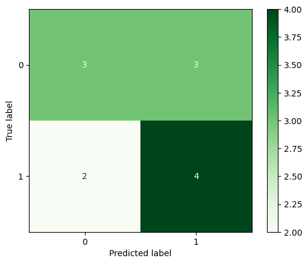

```python
# trying how well a k=3 classifier does
knn_maker_and_scorer(3, scaled_features_train, labels_train, scaled_features_test)
```

#### Tuning knn

With k = 3 the classifier has an accuracy of approx. 58%. To increase the accuracy we need to tune the parameter k. As we only have 39 samples it makes sense to use leave-one-out cross validation to ensure that the training set is as big as possible.

```python
# need to first scale all of the features
scaler=StandardScaler()
scaled_features = scaler.fit_transform(features)


# setting up a grid search to find optimal k
# the model is evaluated for k = 1...30
knn = KNeighborsClassifier()
grid = GridSearchCV(knn, dict(n_neighbors=list(range(1, 30))) , cv=LeaveOneOut(), scoring='accuracy')
grid_search = grid.fit(scaled_features, labels)
print("Best k value: ",grid_search.best_params_)
print("Best accuracy score: ",grid_search.best_score_)
```

```
Best k value:  {'n_neighbors': 2}
Best accuracy score:  0.6153846153846154
```

```
Accuracy Score:  0.5833333333333334

Confusion Matrix:
 [[4 2]
 [3 3]]

Classification Report:
               precision    recall  f1-score   support

           0       0.57      0.67      0.62         6
           1       0.60      0.50      0.55         6

    accuracy                           0.58        12
   macro avg       0.59      0.58      0.58        12
weighted avg       0.59      0.58      0.58        12
```

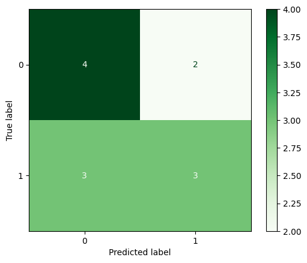

```python
# Grid search told us that k = 2 produces the best result
# seeing how a model with k=2 knn model does:
knn_maker_and_scorer(2, scaled_features_train, labels_train, scaled_features_test)
```

A single model with k=2 and the 30/70 data split did as well as the k=3 model did. Even with an optimized k value there is not enough data after a split to train a good model.

```python
# We can use the cross_va_score function to perform leave one out cross validation with a k=2 model.
knn_cv = KNeighborsClassifier(n_neighbors= 2)
scores = cross_val_score(knn_cv, scaled_features, labels, cv=LeaveOneOut(), scoring='accuracy')
print(scores.mean())
```

```
0.6153846153846154
```

The mean accuracy score produced by the cross validation is the same as the one from grid search, which makes sense because we also had grid search set to perform leave-one-out cross validation.

### Training a model using Naive Bayes classifier

Training another classification model to see how well it does compared to the knn one.

```
Classifier 2 (GaussianNB):
Accuracy: 33.33%
Precision: 33.33%
Recall: 33.33%
F1 Score: 33.33%
Confusion Matrix:
 [[2 4]
 [4 2]]

Classification Report:
               precision    recall  f1-score   support

           0       0.33      0.33      0.33         6
           1       0.33      0.33      0.33         6

    accuracy                           0.33        12
   macro avg       0.33      0.33      0.33        12
weighted avg       0.33      0.33      0.33        12
```

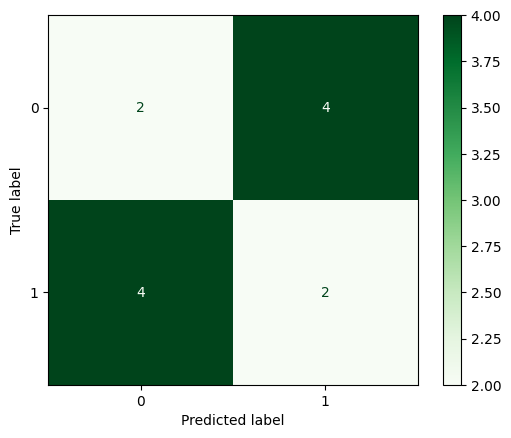

```python
# Create a Naive Bayes classifier
nb = GaussianNB()

# Train the classifier on the training data
nb.fit(scaled_features_train, labels_train)

# Use the trained classifier to predict the class labels of the test data
y_pred = nb.predict(scaled_features_test)

# Evaluate the accuracy of the model
from sklearn.metrics import accuracy_score
nb_accuracy = accuracy_score(labels_test, y_pred)
nb_precision = precision_score(labels_test, y_pred)
nb_recall = recall_score(labels_test, y_pred)
nb_f1 = f1_score(labels_test, y_pred)
nb_classification_report = metrics.classification_report(labels_test, y_pred)
nb_confusion_matrix = metrics.confusion_matrix(labels_test, y_pred)

print("Classifier 2 (GaussianNB):")
print("Accuracy: {:.2f}%".format(nb_accuracy * 100))
print("Precision: {:.2f}%".format(nb_precision * 100))
print("Recall: {:.2f}%".format(nb_recall * 100))
print("F1 Score: {:.2f}%".format(nb_f1 * 100))
print("Confusion Matrix: \n", nb_confusion_matrix, "\n")
print("Classification Report: \n", nb_classification_report)

metrics.plot_confusion_matrix(nb, scaled_features_test, labels_test, cmap='Greens')
plt.show()
```

The model performs worse than the knn one. The model is more prone the false positives and false negatives than true positives or negatives.

```python
# Trying how well the model does with cross validation
scores = cross_val_score(nb, scaled_features, labels, cv=LeaveOneOut(), scoring='accuracy')
print(scores.mean())
```

```
0.46153846153846156
```

By using cross validation the model accuraccy improves a little, but is still very bad.

### Training a decision tree model

```
Classifier: Decision tree
Accuracy: 58.33%
Precision: 60.00%
Recall: 50.00%
F1 Score: 54.55%
Confusion Matrix:
 [[4 2]
 [3 3]]

Classification Report:
               precision    recall  f1-score   support

           0       0.57      0.67      0.62         6
           1       0.60      0.50      0.55         6

    accuracy                           0.58        12
   macro avg       0.59      0.58      0.58        12
weighted avg       0.59      0.58      0.58        12
```

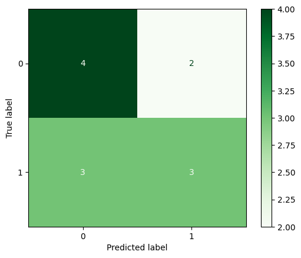

```python
tree = tree.DecisionTreeClassifier(criterion="entropy")
tree.fit(scaled_features_train, labels_train)
tree_pred = tree.predict(scaled_features_test)

# Evaluate the accuracy of the model
t_accuracy = accuracy_score(labels_test, tree_pred)
t_precision = precision_score(labels_test, tree_pred)
t_recall = recall_score(labels_test, tree_pred)
t_f1 = f1_score(labels_test, tree_pred)
t_classification_report = metrics.classification_report(labels_test, tree_pred)
t_confusion_matrix = metrics.confusion_matrix(labels_test, tree_pred)

print("Classifier: Decision tree")
print("Accuracy: {:.2f}%".format(t_accuracy * 100))
print("Precision: {:.2f}%".format(t_precision * 100))
print("Recall: {:.2f}%".format(t_recall * 100))
print("F1 Score: {:.2f}%".format(t_f1 * 100))
print("Confusion Matrix: \n", t_confusion_matrix, "\n")
print("Classification Report: \n", t_classification_report)

metrics.plot_confusion_matrix(tree, scaled_features_test, labels_test, cmap='Greens')
plt.show()
```

The model performs similarly to knn with the same split in data.

```python
tree_scores = cross_val_score(tree, scaled_features, labels, cv=LeaveOneOut(), scoring='accuracy')
print(tree_scores.mean())
```

```
0.41025641025641024
```

Somehow using cross validation does not improve the accuracy of the model.

## Conclusion

### Comparing the models

None of the three models performed particularly well. K neares neighbors did the bes, but even that only had accuracies of about 60% at best. Naive Bayes and decision tree produced worse results than if one were to guess at random.

### Ways to improve the results

- More data
- a more sophisticated filtering method
- could try leaving out the first ~minute of data to decrease the impact of the initial climb
- feature extraction using tsfel or tsfresh woulf give us more features and evaluate their usefullness automatically
  - we tried to use them, but it was too slow
- better feature selection
  - we tried to see how the model performed if we left ou some of the features, but the performance was worse